# RTweet

PLSC 31101

Fall 2019

## Collecting Twitter Data with RTweet

Twitter actually has two separate APIs:

1. The **REST API** allows you to read and write Twitter data. For research purposes, this allows you to search the recent history of tweets and look up specific users.
2. The **Streaming API** allows you to access public data flowing through Twitter in real-time. It requires your R session to be running continuously, but allows you to capture a much larger sample of tweets while avoiding rate limits for the REST API.

There are several packages for R for accessing and searching Twitter. In this unit, we’ll practice using the `RTweet` library, which allows us to easily collect data from Twitter’s REST and stream APIs.

### Setting up `RTweet`

To use `RTweet`, follow these steps:

1. If you don’t have a Twitter account, create one [here](https://twitter.com/i/flow/signup).
2. Install the `RTweet` package from CRAN.
3. Load the package into R.
4. Send a request to Twitter’s API by calling any of the package’s functions, like `search_tweets` or`get_timeline`.
5. Approve the browser popup (to authorize the `rstats2twitter` app).
6. Now, you’re ready to use RTweet!

Let’s go ahead and load `RTweet` along with some other helpful functions:

```r
library(tidyverse)
library(rtweet)
library(lubridate)
library(kableExtra)
```

### UChicago Political Science Prof Tweets

Let’s explore the `RTweet` package to see what we can learn about the tweeting habits of UChicago Political Science faculty.

The function `get_timeline` will pull the most recent `n` number of tweets from a given handle(s). To pull tweets from multiple handles, write out a vector of the handles in the `user` argument.

Let’s pull tweets from five faculty members in the department.

```r
profs <- get_timeline(
  user = c("carsonaust", "profpaulpoast", "pstanpolitics", "rochelleterman", "bobbygulotty"),
  n = 1000
)
kable(head(profs))
```

| user_id | status_id | created_at | screen_name | text | source | display_text_width | reply_to_status_id | reply_to_user_id | reply_to_screen_name | is_quote | is_retweet | favorite_count | retweet_count | quote_count | reply_count | hashtags | symbols | urls_url | urls_t.co | urls_expanded_url | media_url | media_t.co | media_expanded_url | media_type | ext_media_url | ext_media_t.co | ext_media_expanded_url | ext_media_type | mentions_user_id | … |
| --- | --- | --- | --- | --- | --- | --- | --- | --- | --- | --- | --- | --- | --- | --- | --- | --- | --- | --- | --- | --- | --- | --- | --- | --- | --- | --- | --- | --- | --- | --- |
| 805833715 | 1193167372481417216 | 1573308244 | carsonaust | @ProfTalmadge @ProfSaunders @ANewman_forward @Kat_McNamara @IRgetsreal @dbyman @dmedelstein @dhnexon @ErikVoeten @irfannooruddin …and so many more | Twitter Web App | 149 | 1193167371437039617 | 805833715 | carsonaust | FALSE | FALSE | 4 | 0 | NA | NA | NA | NA | NA | NA | NA | NA | NA | NA | NA | NA | NA | NA | NA | c(“1036404458161426432”, “1636747982”, “821082773884637184”, “256659585”, “2618035261”, “297648980”, “718793610”, “55015468”, “2364189422”, “2826743402”) | … |
| 805833715 | 1193167371437039617 | 1573308243 | carsonaust | Really excited to head to DC for this event on Monday @MortaraCenter. Truly honored to be receiving the Lepgold Book Prize for *Secret Wars*. And bonus! A chance to see some of the many amazing folks … | Twitter Web App | 237 | NA | NA | NA | FALSE | FALSE | 103 | 6 | NA | NA | NA | NA | mortara.georgetown.edu/event/lecture-… | https://t.co/DpBEozAJQR | https://mortara.georgetown.edu/event/lecture-by-lepgold-book-prize-winner-austin-carson/ | NA | NA | NA | NA | NA | NA | NA | NA | 48739999 | … |
| 805833715 | 1192955815625469953 | 1573257805 | carsonaust | All of you are too kind! @mevers90 was quick on the draw. Am all set, thank you! | Twitter for iPhone | 80 | 1192938163993493509 | 805833715 | carsonaust | FALSE | FALSE | 2 | 0 | NA | NA | NA | NA | NA | NA | NA | NA | NA | NA | NA | NA | NA | NA | NA | 1702865540 | … |
| 805833715 | 1192938163993493509 | 1573253596 | carsonaust | Anyone have access to this? Mapping fears: the use of commercial high-resolution satellite imagery in international affairs S Livingston, WL Robinson - Astropolitics, 2003 https://t.co/CbP7h6qG1G | Twitter Web App | 198 | NA | NA | NA | FALSE | FALSE | 3 | 1 | NA | NA | NA | NA | tandfonline.com/doi/abs/10.108… | https://t.co/CbP7h6qG1G | https://www.tandfonline.com/doi/abs/10.1080/14777620312331269909 | NA | NA | NA | NA | NA | NA | NA | NA | NA | … |
| 805833715 | 1192858707253702657 | 1573234652 | carsonaust | @na_paraiso @krasnican_ No that’s plagiarism. An F! | Twitter Web App | 27 | 1192857507699539971 | 702215720 | na_paraiso | FALSE | FALSE | 8 | 0 | NA | NA | NA | NA | NA | NA | NA | NA | NA | NA | NA | NA | NA | NA | NA | c(“702215720”, “1001654539752271874”) | … |
| 805833715 | 1192855989902618624 | 1573234004 | carsonaust | Well played, sir! &lt;opens gradebook&gt; &lt;goes to “Krasnican&gt; &lt;enters”A+“&gt; https://t.co/fbOPeJpcVM | Twitter Web App | 89 | NA | NA | NA | TRUE | FALSE | 36 | 0 | NA | NA | NA | NA | twitter.com/krasnican_/sta… | https://t.co/fbOPeJpcVM | https://twitter.com/krasnican_/status/1192491736670625793 | NA | NA | NA | NA | NA | NA | NA | NA | NA | … |

Now, let’s visualize which professors are tweeting the most, by week.

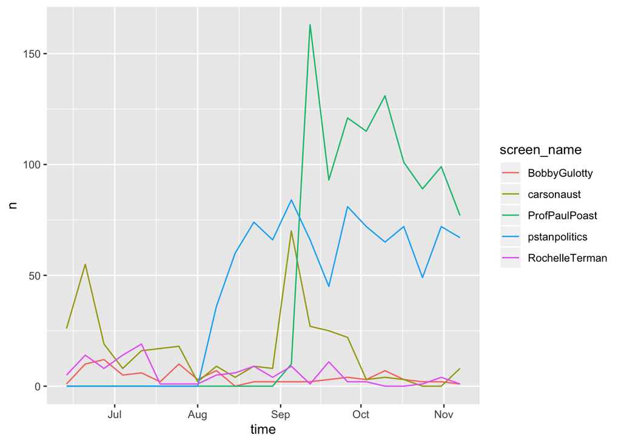

```r
profs %>%
  group_by(screen_name) %>%
  mutate(created_at = as.Date(created_at)) %>%
  filter(created_at >= "2019-06-15") %>%
  ts_plot(by = "week")
```

### Hashtags and Text Strings

We can also use `RTweet` to explore certain hashtags or text strings.

Let’s take Duke Ellington again – we can use `search_tweets` to pull the most recent n number of tweets that include the hashtag `#DukeEllington` or the string `"Duke Ellington"`.

#### Hashtag Challenge

Using the documentation for `search_tweets` as a guide, try pulling the 2,000 most recent tweets that include `#DukeEllington` or `"Duke Ellington"` – be sure to exclude retweets from the query.

1. Why didn’t your query return 2,000 results?
2. Identify the user that has used either the hashtag or the string in the greatest number of tweets – where is this user from?

```r
duke <- search_tweets(
  q = '#DukeEllington OR "Duke Ellington"',
  n = 2000,
  include_rts = FALSE
)

duke %>%
  group_by(user_id, location) %>%
  summarise(n = n()) %>%
  arrange(desc(n))
```

```
## # A tibble: 720 x 3
## # Groups:   user_id [720]
##    user_id             location                           n
##    <chr>               <chr>                          <int>
##  1 2561373848          Florida, USA                      85
##  2 764290456599396353  Rochester, New York               52
##  3 1022122568004894720 ""                                31
##  4 1030069194539368448 ""                                31
##  5 714738130557992960  Chiclana de la Frontera, Spain    24
##  6 826869114           Paris, Ile-de-France              18
##  7 1048404121206714369 ""                                14
##  8 1260813006          Redmond, WA                       13
##  9 1026490600349229058 United States                     11
## 10 3047965474          Napoli                            11
## # … with 710 more rows
```